# Quick tutorial for linear regression

François Birgand

4/13/2021

## Creating linear regression between y and x

Let us take these two variables x and y and plot them together

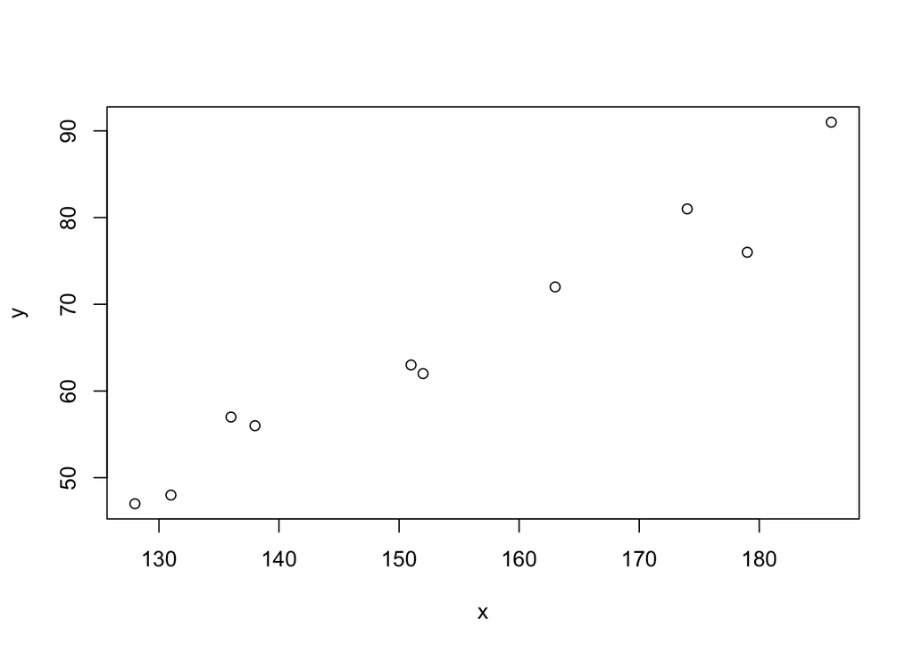

```r
x <- c(151, 174, 138, 186, 128, 136, 179, 163, 152, 131)
y <- c(63, 81, 56, 91, 47, 57, 76, 72, 62, 48)

plot(x,y)
```

Now, we want to find a linear model `(lm)` that best fits through the cloud of points such that in the end we will get a model $y = ax + b$, and we want to find the two coefficients $a$ and $b$.

for this we use the following expression where a variable named `relation` has all the attibutes associated with a linear regression of y as a function of x. In this form, it assumes that the intercept is not 0

```r
relation <- lm(y~x)
```

### How to retrieve some of the values associated with the linear model

#### When intercept is not 0

```r
names(relation) #
```

```
##  [1] "coefficients"  "residuals"     "effects"       "rank"
##  [5] "fitted.values" "assign"        "qr"            "df.residual"
##  [9] "xlevels"       "call"          "terms"         "model"
```

gives quite a few important parameters that are included in the object relation.

```r
summary(relation)
```

```
##
## Call:
## lm(formula = y ~ x)
##
## Residuals:
##     Min      1Q  Median      3Q     Max
## -6.3002 -1.6629  0.0412  1.8944  3.9775
##
## Coefficients:
##              Estimate Std. Error t value Pr(>|t|)
## (Intercept) -38.45509    8.04901  -4.778  0.00139 **
## x             0.67461    0.05191  12.997 1.16e-06 ***
## ---
## Signif. codes:  0 '***' 0.001 '**' 0.01 '*' 0.05 '.' 0.1 ' ' 1
##
## Residual standard error: 3.253 on 8 degrees of freedom
## Multiple R-squared:  0.9548, Adjusted R-squared:  0.9491
## F-statistic: 168.9 on 1 and 8 DF,  p-value: 1.164e-06
```

gives you a summary of important (same as above + additional) values compiled into a readable table. To obtain some of the values like the R² or other things.

```r
names(summary(relation))
```

```
##  [1] "call"          "terms"         "residuals"     "coefficients"
##  [5] "aliased"       "sigma"         "df"            "r.squared"
##  [9] "adj.r.squared" "fstatistic"    "cov.unscaled"
```

gives you the names of all the variables that appear as a readable table when typing `summary(relation)`.

```r
relation$coefficients # is a vector that gives the coefficients of the regression
```

```
## (Intercept)           x
## -38.4550871   0.6746104
```

```r
relation$coefficients[1] # gives the intercept of the regression line or the coefficient b
```

```
## (Intercept)
##   -38.45509
```

```r
relation$coefficients[2] # gives the slope of the regression line or the coefficient a
```

```
##         x
## 0.6746104
```

gives you the names of all the variables that appear as a readable table when typing `summary(relation)`.

You may thus also retrieve the coefficients of the regression using

```r
summary(relation)$coefficients #
```

```
##                Estimate Std. Error   t value     Pr(>|t|)
## (Intercept) -38.4550871 8.04901330 -4.777615 1.394928e-03
## x             0.6746104 0.05190514 12.996987 1.164405e-06
```

You now have also access to the standard error on the intercept (first row) and on the slope (second row), the t value gives the results of the t-test associated with testing the significance of the parameter listed in the first column, and Pr(>|t|) gives you the p-value for that t-test.

```r
# You could thus retrieve the value for the slope using
summary(relation)$coefficients[2,1] #second row of the first column
```

```
## [1] 0.6746104
```

```r
# You could thus retrieve the value for the intercept using
summary(relation)$coefficients[1,1] #first row of the first column
```

```
## [1] -38.45509
```

So essentially `relation$coefficients[1]` is the same as `summary(relation)$coefficients[1,1]` and `relation$coefficients[2]` is the same as `summary(relation)$coefficients[2,1]`.

So may use the values of the coefficients you have found to calculate anything you need with them.

#### When intercept is 0

You essentially use the same tools but the synthax for the regression becomes:

```r
relation_no_intercept <- lm(y~x+0)
relation_no_intercept$coefficients # now only has one value for the slope
```

```
##         x
## 0.4286611
```

### How to plot the linear model

There are several ways to plot the variables. The first one is to use the function `abline` as below. That is very efficient.

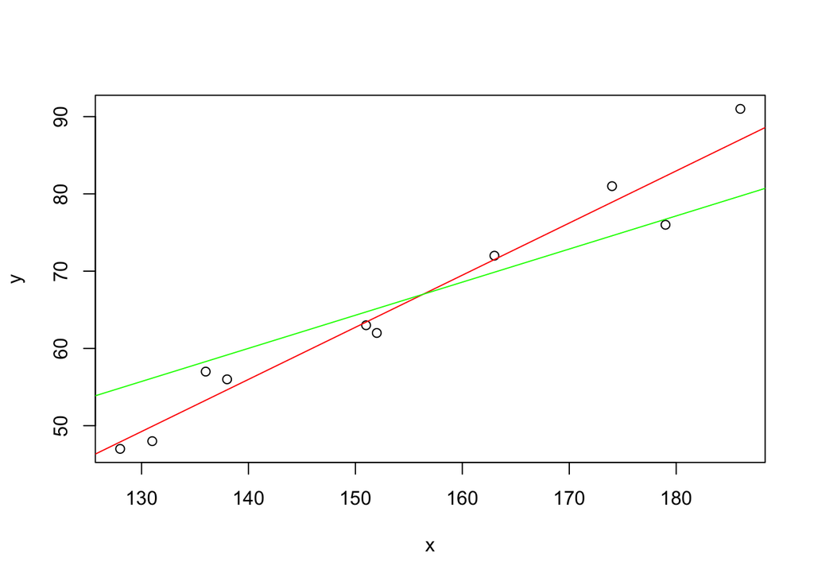

```r
x <- c(151, 174, 138, 186, 128, 136, 179, 163, 152, 131)
y <- c(63, 81, 56, 91, 47, 57, 76, 72, 62, 48)


plot(x,y)
abline(relation,col='red')
abline(relation_no_intercept,col='green')
```

You may want to express directly the expression of the coefficients in the equation just like below.

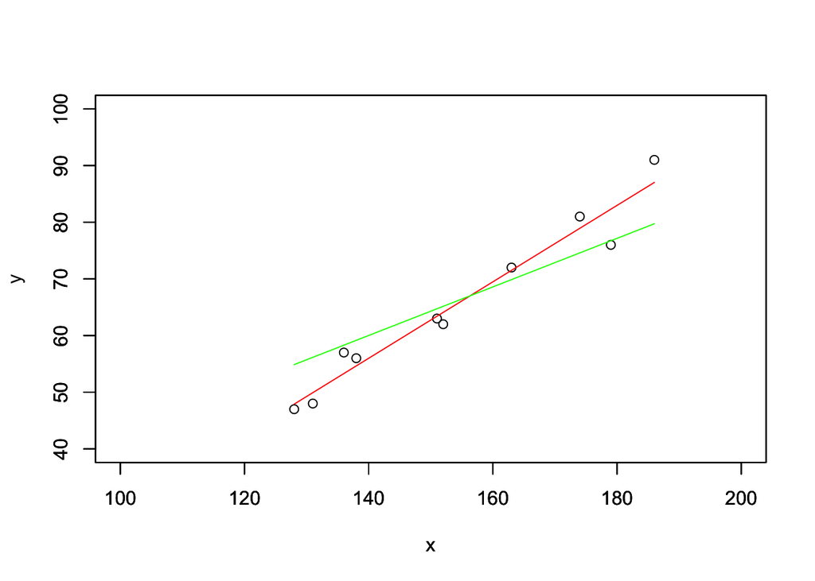

```r
xlim=c(100,200);ylim=c(40,100) # important to define x and y scales now as you are adding a new plot and the automatic scale
# adjustment may not be the same for both curves
plot(x,y, xlim=xlim,ylim=ylim)

a <- relation$coefficients[2]
b <- relation$coefficients[1]
alpha <- relation_no_intercept$coefficients

par(new=TRUE) # just tells R to wait to plot an additional curve

plot(x,a*x+b, xlim=xlim,ylim=ylim, type='l', col = 'red',ylab='')

par(new=TRUE)
plot(x,alpha*x, xlim=xlim,ylim=ylim, type='l', col = 'green',ylab='')
```

But you may also use a totally different `x` in the plotting.

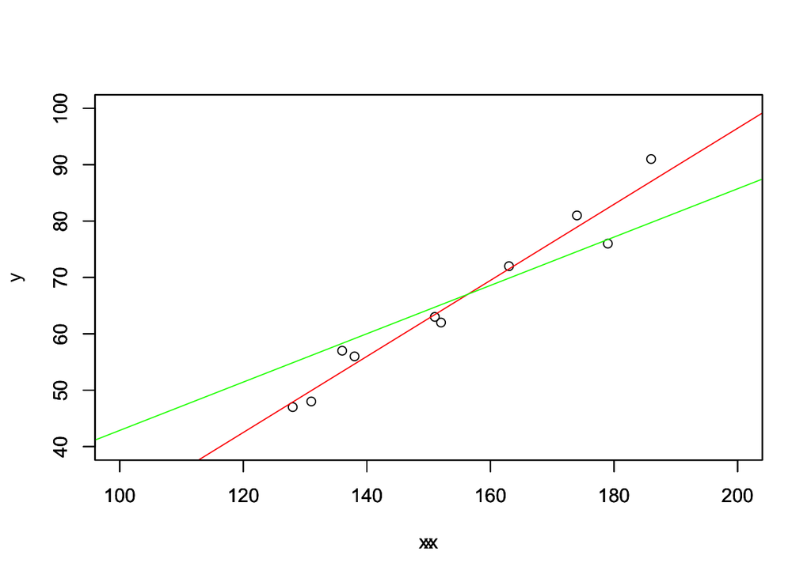

```r
xx <- seq(0,300,by=1) # xx is now a vector from 0 to 300 at increment equal to 1

xlim=c(100,200);ylim=c(40,100) # important to define x and y scales now as you are adding a new plot and the automatic scale
# adjustment may not be the same for both curves
plot(x,y, xlim=xlim,ylim=ylim)

a <- relation$coefficients[2]
b <- relation$coefficients[1]
alpha <- relation_no_intercept$coefficients

par(new=TRUE) # just tells R to wait to plot an additional curve

plot(xx,a*xx+b, xlim=xlim,ylim=ylim, type='l', col = 'red',ylab='')

par(new=TRUE)
plot(xx,alpha*xx, xlim=xlim,ylim=ylim, type='l', col = 'green',ylab='')
```